# Risk Factor Analysis

## Outcome Variable

**Outcome Variable:** y_rate_haz

## Predictor Variables

**Intervention Variable:** hdlvry

**Adjustment Set:**

- arm
- sex
- W_mage
- meducyrs
- feducyrs
- hhwealth_quart
- W_nrooms
- brthmon
- impfloor
- impsan
- delta_W_mage
- delta_meducyrs
- delta_feducyrs
- delta_hhwealth_quart
- delta_W_nrooms
- delta_brthmon
- delta_impfloor
- delta_impsan

## Stratifying Variables

The analysis was stratified on these variable(s):

- agecat
- studyid
- country

## Data Summary

| agecat | studyid | country | hdlvry | n_cell | n |
| --- | --- | --- | --- | --- | --- |
| 0-3 months | ki1000108-CMC-V-BCS-2002 | INDIA | 0 | 87 | 87 |
| 0-3 months | ki1000108-CMC-V-BCS-2002 | INDIA | 1 | 0 | 87 |
| 0-3 months | ki1000108-IRC | INDIA | 0 | 370 | 377 |
| 0-3 months | ki1000108-IRC | INDIA | 1 | 7 | 377 |
| 0-3 months | ki1000109-EE | PAKISTAN | 0 | 386 | 590 |
| 0-3 months | ki1000109-EE | PAKISTAN | 1 | 204 | 590 |
| 0-3 months | ki1000304b-SAS-CompFeed | INDIA | 0 | 127 | 976 |
| 0-3 months | ki1000304b-SAS-CompFeed | INDIA | 1 | 849 | 976 |
| 0-3 months | ki1017093b-PROVIDE | BANGLADESH | 0 | 474 | 634 |
| 0-3 months | ki1017093b-PROVIDE | BANGLADESH | 1 | 160 | 634 |
| 0-3 months | ki1017093c-NIH-Crypto | BANGLADESH | 0 | 557 | 720 |
| 0-3 months | ki1017093c-NIH-Crypto | BANGLADESH | 1 | 163 | 720 |
| 0-3 months | ki1135781-COHORTS | INDIA | 0 | 2863 | 4580 |
| 0-3 months | ki1135781-COHORTS | INDIA | 1 | 1717 | 4580 |
| 0-3 months | kiGH5241-JiVitA-3 | BANGLADESH | 0 | 66 | 626 |
| 0-3 months | kiGH5241-JiVitA-3 | BANGLADESH | 1 | 560 | 626 |
| 0-3 months | kiGH5241-JiVitA-4 | BANGLADESH | 0 | 738 | 3592 |
| 0-3 months | kiGH5241-JiVitA-4 | BANGLADESH | 1 | 2854 | 3592 |
| 3-6 months | ki1000108-CMC-V-BCS-2002 | INDIA | 0 | 298 | 305 |
| 3-6 months | ki1000108-CMC-V-BCS-2002 | INDIA | 1 | 7 | 305 |
| 3-6 months | ki1000108-IRC | INDIA | 0 | 389 | 397 |
| 3-6 months | ki1000108-IRC | INDIA | 1 | 8 | 397 |
| 3-6 months | ki1000109-EE | PAKISTAN | 0 | 436 | 658 |
| 3-6 months | ki1000109-EE | PAKISTAN | 1 | 222 | 658 |
| 3-6 months | ki1000304b-SAS-CompFeed | INDIA | 0 | 124 | 919 |
| 3-6 months | ki1000304b-SAS-CompFeed | INDIA | 1 | 795 | 919 |
| 3-6 months | ki1017093b-PROVIDE | BANGLADESH | 0 | 428 | 574 |
| 3-6 months | ki1017093b-PROVIDE | BANGLADESH | 1 | 146 | 574 |
| 3-6 months | ki1017093c-NIH-Crypto | BANGLADESH | 0 | 536 | 695 |
| 3-6 months | ki1017093c-NIH-Crypto | BANGLADESH | 1 | 159 | 695 |

[output cut: 52 more lines]

The following strata were considered:

- agecat: 0-3 months, studyid: ki1000108-CMC-V-BCS-2002, country: INDIA
- agecat: 0-3 months, studyid: ki1000108-IRC, country: INDIA
- agecat: 0-3 months, studyid: ki1000109-EE, country: PAKISTAN
- agecat: 0-3 months, studyid: ki1000304b-SAS-CompFeed, country: INDIA
- agecat: 0-3 months, studyid: ki1017093b-PROVIDE, country: BANGLADESH
- agecat: 0-3 months, studyid: ki1017093c-NIH-Crypto, country: BANGLADESH
- agecat: 0-3 months, studyid: ki1135781-COHORTS, country: INDIA
- agecat: 0-3 months, studyid: kiGH5241-JiVitA-3, country: BANGLADESH
- agecat: 0-3 months, studyid: kiGH5241-JiVitA-4, country: BANGLADESH
- agecat: 12-24 months, studyid: ki1000108-CMC-V-BCS-2002, country: INDIA
- agecat: 12-24 months, studyid: ki1000108-IRC, country: INDIA
- agecat: 12-24 months, studyid: ki1017093b-PROVIDE, country: BANGLADESH
- agecat: 12-24 months, studyid: ki1017093c-NIH-Crypto, country: BANGLADESH
- agecat: 12-24 months, studyid: ki1066203-TanzaniaChild2, country: TANZANIA, UNITED REPUBLIC OF
- agecat: 12-24 months, studyid: ki1113344-GMS-Nepal, country: NEPAL
- agecat: 12-24 months, studyid: ki1135781-COHORTS, country: INDIA
- agecat: 12-24 months, studyid: kiGH5241-JiVitA-3, country: BANGLADESH
- agecat: 12-24 months, studyid: kiGH5241-JiVitA-4, country: BANGLADESH
- agecat: 3-6 months, studyid: ki1000108-CMC-V-BCS-2002, country: INDIA
- agecat: 3-6 months, studyid: ki1000108-IRC, country: INDIA
- agecat: 3-6 months, studyid: ki1000109-EE, country: PAKISTAN
- agecat: 3-6 months, studyid: ki1000304b-SAS-CompFeed, country: INDIA
- agecat: 3-6 months, studyid: ki1017093b-PROVIDE, country: BANGLADESH
- agecat: 3-6 months, studyid: ki1017093c-NIH-Crypto, country: BANGLADESH
- agecat: 3-6 months, studyid: ki1066203-TanzaniaChild2, country: TANZANIA, UNITED REPUBLIC OF
- agecat: 3-6 months, studyid: ki1113344-GMS-Nepal, country: NEPAL
- agecat: 3-6 months, studyid: ki1135781-COHORTS, country: INDIA
- agecat: 3-6 months, studyid: kiGH5241-JiVitA-3, country: BANGLADESH
- agecat: 3-6 months, studyid: kiGH5241-JiVitA-4, country: BANGLADESH
- agecat: 6-12 months, studyid: ki1000108-CMC-V-BCS-2002, country: INDIA
- agecat: 6-12 months, studyid: ki1000108-IRC, country: INDIA
- agecat: 6-12 months, studyid: ki1000109-EE, country: PAKISTAN
- agecat: 6-12 months, studyid: ki1000304b-SAS-CompFeed, country: INDIA
- agecat: 6-12 months, studyid: ki1000304b-SAS-FoodSuppl, country: INDIA
- agecat: 6-12 months, studyid: ki1017093b-PROVIDE, country: BANGLADESH
- agecat: 6-12 months, studyid: ki1017093c-NIH-Crypto, country: BANGLADESH
- agecat: 6-12 months, studyid: ki1066203-TanzaniaChild2, country: TANZANIA, UNITED REPUBLIC OF
- agecat: 6-12 months, studyid: ki1113344-GMS-Nepal, country: NEPAL
- agecat: 6-12 months, studyid: ki1135781-COHORTS, country: INDIA
- agecat: 6-12 months, studyid: kiGH5241-JiVitA-3, country: BANGLADESH
- agecat: 6-12 months, studyid: kiGH5241-JiVitA-4, country: BANGLADESH

### Dropped Strata

- agecat: 0-3 months, studyid: ki1000108-CMC-V-BCS-2002, country: INDIA
- agecat: 6-12 months, studyid: ki1000109-EE, country: PAKISTAN
- agecat: 12-24 months, studyid: ki1066203-TanzaniaChild2, country: TANZANIA, UNITED REPUBLIC OF

## Methods Detail

We’re interested in the causal parameters $E[Y_a]$ for all values of $a \in \mathcal{A}$. These parameters represent the mean outcome if, possibly contrary to fact, we intervened to set all units to have $A=a$. Under the randomization and positivity assumptions, these are identified by the statistical parameters $\psi_a=E_W[E_{Y|A,W}(Y|A=a,W)]$. In addition, we’re interested in the mean of $Y$, $E[Y]$ under no intervention (the observed mean). We will estimate these parameters by using SuperLearner to fit the relevant likelihood factors – $E_{Y|A,W}(Y|A=a,W)$ and $p(A=a|W)$, and then updating our likelihood fit using a joint TMLE.

For unadjusted analyses ($W=\{\}$), initial likelihoods were estimated using Lrnr_glm to estimate the simple $E(Y|A)$ and Lrnr_mean to estimate $p(A)$. For adjusted analyses, a small library containing Lrnr_glmnet, Lrnr_xgboost, and Lrnr_mean was used.

Having estimated these parameters, we will then use the delta method to estimate relative risks and attributable risks relative to a prespecified baseline level of $A$.

# Results Detail

## Results Plots

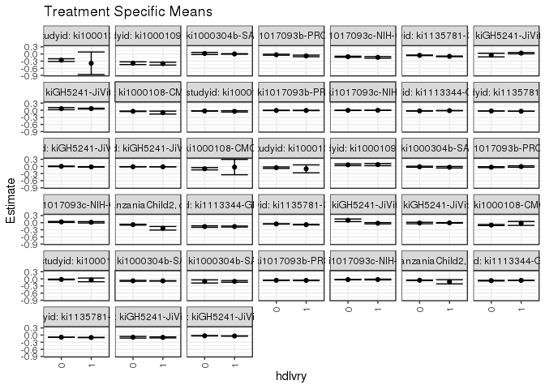

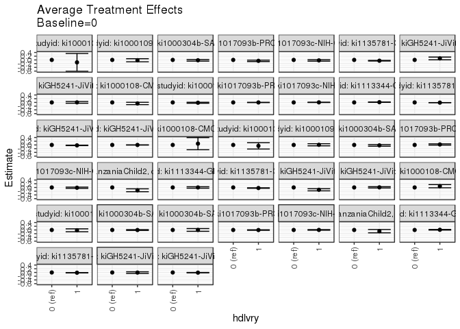

## Results Table

### Parameter: TSM

| agecat | studyid | country | intervention_level | baseline_level | estimate | ci_lower | ci_upper |
| --- | --- | --- | --- | --- | --- | --- | --- |
| 0-3 months | ki1000108-IRC | INDIA | 0 | NA | -0.2570446 | -0.3133181 | -0.2007712 |
| 0-3 months | ki1000108-IRC | INDIA | 1 | NA | -0.3890887 | -0.8631374 | 0.0849601 |
| 0-3 months | ki1000109-EE | PAKISTAN | 0 | NA | -0.3869272 | -0.4440923 | -0.3297622 |
| 0-3 months | ki1000109-EE | PAKISTAN | 1 | NA | -0.4053041 | -0.4651269 | -0.3454813 |
| 0-3 months | ki1000304b-SAS-CompFeed | INDIA | 0 | NA | 0.0228130 | -0.0218478 | 0.0674739 |
| 0-3 months | ki1000304b-SAS-CompFeed | INDIA | 1 | NA | 0.0034404 | -0.0076868 | 0.0145675 |
| 0-3 months | ki1017093b-PROVIDE | BANGLADESH | 0 | NA | -0.0309691 | -0.0521539 | -0.0097843 |
| 0-3 months | ki1017093b-PROVIDE | BANGLADESH | 1 | NA | -0.0802096 | -0.1124994 | -0.0479198 |
| 0-3 months | ki1017093c-NIH-Crypto | BANGLADESH | 0 | NA | -0.1137850 | -0.1344735 | -0.0930965 |
| 0-3 months | ki1017093c-NIH-Crypto | BANGLADESH | 1 | NA | -0.1399778 | -0.1738725 | -0.1060831 |
| 0-3 months | ki1135781-COHORTS | INDIA | 0 | NA | -0.0558488 | -0.0663087 | -0.0453888 |
| 0-3 months | ki1135781-COHORTS | INDIA | 1 | NA | -0.0989377 | -0.1118977 | -0.0859777 |
| 0-3 months | kiGH5241-JiVitA-3 | BANGLADESH | 0 | NA | -0.0431009 | -0.1197318 | 0.0335300 |
| 0-3 months | kiGH5241-JiVitA-3 | BANGLADESH | 1 | NA | 0.0360682 | 0.0078452 | 0.0642913 |
| 0-3 months | kiGH5241-JiVitA-4 | BANGLADESH | 0 | NA | 0.0654942 | 0.0220740 | 0.1089145 |
| 0-3 months | kiGH5241-JiVitA-4 | BANGLADESH | 1 | NA | 0.0683134 | 0.0524306 | 0.0841961 |
| 3-6 months | ki1000108-CMC-V-BCS-2002 | INDIA | 0 | NA | -0.0970669 | -0.1454070 | -0.0487268 |
| 3-6 months | ki1000108-CMC-V-BCS-2002 | INDIA | 1 | NA | -0.0276755 | -0.3500119 | 0.2946609 |
| 3-6 months | ki1000108-IRC | INDIA | 0 | NA | -0.0508820 | -0.0813924 | -0.0203717 |
| 3-6 months | ki1000108-IRC | INDIA | 1 | NA | -0.1009918 | -0.2683302 | 0.0663466 |
| 3-6 months | ki1000109-EE | PAKISTAN | 0 | NA | 0.0681485 | 0.0333584 | 0.1029386 |
| 3-6 months | ki1000109-EE | PAKISTAN | 1 | NA | 0.0770265 | 0.0323733 | 0.1216798 |
| 3-6 months | ki1000304b-SAS-CompFeed | INDIA | 0 | NA | -0.0125462 | -0.0340600 | 0.0089676 |
| 3-6 months | ki1000304b-SAS-CompFeed | INDIA | 1 | NA | -0.0349547 | -0.0665479 | -0.0033615 |
| 3-6 months | ki1017093b-PROVIDE | BANGLADESH | 0 | NA | -0.0312291 | -0.0502404 | -0.0122179 |
| 3-6 months | ki1017093b-PROVIDE | BANGLADESH | 1 | NA | -0.0055448 | -0.0345302 | 0.0234406 |
| 3-6 months | ki1017093c-NIH-Crypto | BANGLADESH | 0 | NA | 0.0303438 | 0.0110586 | 0.0496289 |
| 3-6 months | ki1017093c-NIH-Crypto | BANGLADESH | 1 | NA | 0.0152570 | -0.0141503 | 0.0446643 |
| 3-6 months | ki1066203-TanzaniaChild2 | TANZANIA, UNITED REPUBLIC OF | 0 | NA | -0.0859565 | -0.1031341 | -0.0687789 |
| 3-6 months | ki1066203-TanzaniaChild2 | TANZANIA, UNITED REPUBLIC OF | 1 | NA | -0.2364793 | -0.3120825 | -0.1608761 |
| 3-6 months | ki1113344-GMS-Nepal | NEPAL | 0 | NA | -0.1637237 | -0.1956877 | -0.1317597 |
| 3-6 months | ki1113344-GMS-Nepal | NEPAL | 1 | NA | -0.1639957 | -0.1859777 | -0.1420137 |
| 3-6 months | ki1135781-COHORTS | INDIA | 0 | NA | -0.0544297 | -0.0628758 | -0.0459837 |
| 3-6 months | ki1135781-COHORTS | INDIA | 1 | NA | -0.0850318 | -0.0951678 | -0.0748959 |
| 3-6 months | kiGH5241-JiVitA-3 | BANGLADESH | 0 | NA | 0.0991758 | 0.0463608 | 0.1519908 |
| 3-6 months | kiGH5241-JiVitA-3 | BANGLADESH | 1 | NA | -0.0260167 | -0.0543823 | 0.0023489 |
| 3-6 months | kiGH5241-JiVitA-4 | BANGLADESH | 0 | NA | -0.0148088 | -0.0468193 | 0.0172017 |
| 3-6 months | kiGH5241-JiVitA-4 | BANGLADESH | 1 | NA | -0.0093761 | -0.0240291 | 0.0052768 |
| 6-12 months | ki1000108-CMC-V-BCS-2002 | INDIA | 0 | NA | -0.1006331 | -0.1216225 | -0.0796436 |
| 6-12 months | ki1000108-CMC-V-BCS-2002 | INDIA | 1 | NA | -0.0320275 | -0.1157735 | 0.0517186 |
| 6-12 months | ki1000108-IRC | INDIA | 0 | NA | -0.0256573 | -0.0387196 | -0.0125950 |
| 6-12 months | ki1000108-IRC | INDIA | 1 | NA | -0.0435471 | -0.1211440 | 0.0340497 |
| 6-12 months | ki1000304b-SAS-CompFeed | INDIA | 0 | NA | -0.0833583 | -0.1016392 | -0.0650775 |
| 6-12 months | ki1000304b-SAS-CompFeed | INDIA | 1 | NA | -0.0864312 | -0.0938828 | -0.0789795 |
| 6-12 months | ki1000304b-SAS-FoodSuppl | INDIA | 0 | NA | -0.1095827 | -0.1750878 | -0.0440775 |
| 6-12 months | ki1000304b-SAS-FoodSuppl | INDIA | 1 | NA | -0.1076451 | -0.1422404 | -0.0730497 |
| 6-12 months | ki1017093b-PROVIDE | BANGLADESH | 0 | NA | -0.0615159 | -0.0696801 | -0.0533516 |
| 6-12 months | ki1017093b-PROVIDE | BANGLADESH | 1 | NA | -0.0655002 | -0.0781451 | -0.0528554 |
| 6-12 months | ki1017093c-NIH-Crypto | BANGLADESH | 0 | NA | -0.0321361 | -0.0405717 | -0.0237004 |
| 6-12 months | ki1017093c-NIH-Crypto | BANGLADESH | 1 | NA | -0.0296161 | -0.0439413 | -0.0152909 |
| 6-12 months | ki1066203-TanzaniaChild2 | TANZANIA, UNITED REPUBLIC OF | 0 | NA | -0.0603615 | -0.0697573 | -0.0509658 |
| 6-12 months | ki1066203-TanzaniaChild2 | TANZANIA, UNITED REPUBLIC OF | 1 | NA | -0.1247121 | -0.2131417 | -0.0362826 |
| 6-12 months | ki1113344-GMS-Nepal | NEPAL | 0 | NA | -0.0750207 | -0.0882511 | -0.0617903 |
| 6-12 months | ki1113344-GMS-Nepal | NEPAL | 1 | NA | -0.0644619 | -0.0744434 | -0.0544804 |
| 6-12 months | ki1135781-COHORTS | INDIA | 0 | NA | -0.0904940 | -0.0956561 | -0.0853319 |
| 6-12 months | ki1135781-COHORTS | INDIA | 1 | NA | -0.1028694 | -0.1093475 | -0.0963914 |
| 6-12 months | kiGH5241-JiVitA-3 | BANGLADESH | 0 | NA | -0.0930467 | -0.1270067 | -0.0590867 |
| 6-12 months | kiGH5241-JiVitA-3 | BANGLADESH | 1 | NA | -0.0980818 | -0.1195613 | -0.0766023 |
| 6-12 months | kiGH5241-JiVitA-4 | BANGLADESH | 0 | NA | -0.0307805 | -0.0387482 | -0.0228127 |
| 6-12 months | kiGH5241-JiVitA-4 | BANGLADESH | 1 | NA | -0.0393138 | -0.0445364 | -0.0340913 |
| 12-24 months | ki1000108-CMC-V-BCS-2002 | INDIA | 0 | NA | -0.0450653 | -0.0551951 | -0.0349355 |
| 12-24 months | ki1000108-CMC-V-BCS-2002 | INDIA | 1 | NA | -0.0998494 | -0.1614239 | -0.0382749 |
| 12-24 months | ki1000108-IRC | INDIA | 0 | NA | -0.0314316 | -0.0386198 | -0.0242435 |
| 12-24 months | ki1000108-IRC | INDIA | 1 | NA | -0.0481150 | -0.0746149 | -0.0216151 |
| 12-24 months | ki1017093b-PROVIDE | BANGLADESH | 0 | NA | -0.0089253 | -0.0133840 | -0.0044667 |
| 12-24 months | ki1017093b-PROVIDE | BANGLADESH | 1 | NA | -0.0097760 | -0.0165961 | -0.0029560 |
| 12-24 months | ki1017093c-NIH-Crypto | BANGLADESH | 0 | NA | -0.0065121 | -0.0111005 | -0.0019238 |
| 12-24 months | ki1017093c-NIH-Crypto | BANGLADESH | 1 | NA | -0.0028515 | -0.0096999 | 0.0039969 |
| 12-24 months | ki1113344-GMS-Nepal | NEPAL | 0 | NA | -0.0300335 | -0.0373648 | -0.0227022 |
| 12-24 months | ki1113344-GMS-Nepal | NEPAL | 1 | NA | -0.0175823 | -0.0238782 | -0.0112864 |
| 12-24 months | ki1135781-COHORTS | INDIA | 0 | NA | -0.0326008 | -0.0350129 | -0.0301887 |
| 12-24 months | ki1135781-COHORTS | INDIA | 1 | NA | -0.0436488 | -0.0468001 | -0.0404976 |
| 12-24 months | kiGH5241-JiVitA-3 | BANGLADESH | 0 | NA | 0.0036770 | -0.0078587 | 0.0152128 |
| 12-24 months | kiGH5241-JiVitA-3 | BANGLADESH | 1 | NA | -0.0197782 | -0.0296548 | -0.0099016 |
| 12-24 months | kiGH5241-JiVitA-4 | BANGLADESH | 0 | NA | -0.0134625 | -0.0173675 | -0.0095576 |
| 12-24 months | kiGH5241-JiVitA-4 | BANGLADESH | 1 | NA | -0.0143657 | -0.0166797 | -0.0120517 |

### Parameter: E(Y)

| agecat | studyid | country | intervention_level | baseline_level | estimate | ci_lower | ci_upper |
| --- | --- | --- | --- | --- | --- | --- | --- |
| 0-3 months | ki1000108-IRC | INDIA | NA | NA | -0.2594964 | -0.3154509 | -0.2035418 |
| 0-3 months | ki1000109-EE | PAKISTAN | NA | NA | -0.3932813 | -0.4361258 | -0.3504368 |
| 0-3 months | ki1000304b-SAS-CompFeed | INDIA | NA | NA | 0.0087093 | -0.0074467 | 0.0248652 |
| 0-3 months | ki1017093b-PROVIDE | BANGLADESH | NA | NA | -0.0413143 | -0.0594662 | -0.0231624 |
| 0-3 months | ki1017093c-NIH-Crypto | BANGLADESH | NA | NA | -0.1220821 | -0.1402761 | -0.1038881 |
| 0-3 months | ki1135781-COHORTS | INDIA | NA | NA | -0.0699385 | -0.0782973 | -0.0615796 |
| 0-3 months | kiGH5241-JiVitA-3 | BANGLADESH | NA | NA | 0.0349097 | 0.0045006 | 0.0653188 |
| 0-3 months | kiGH5241-JiVitA-4 | BANGLADESH | NA | NA | 0.0670726 | 0.0519630 | 0.0821823 |
| 3-6 months | ki1000108-CMC-V-BCS-2002 | INDIA | NA | NA | -0.0954743 | -0.1432951 | -0.0476535 |
| 3-6 months | ki1000108-IRC | INDIA | NA | NA | -0.0518918 | -0.0819849 | -0.0217987 |
| 3-6 months | ki1000109-EE | PAKISTAN | NA | NA | 0.0708740 | 0.0425313 | 0.0992167 |
| 3-6 months | ki1000304b-SAS-CompFeed | INDIA | NA | NA | -0.0318535 | -0.0595705 | -0.0041366 |
| 3-6 months | ki1017093b-PROVIDE | BANGLADESH | NA | NA | -0.0272428 | -0.0436954 | -0.0107902 |
| 3-6 months | ki1017093c-NIH-Crypto | BANGLADESH | NA | NA | 0.0267740 | 0.0099602 | 0.0435879 |
| 3-6 months | ki1066203-TanzaniaChild2 | TANZANIA, UNITED REPUBLIC OF | NA | NA | -0.0872216 | -0.1042720 | -0.0701712 |
| 3-6 months | ki1113344-GMS-Nepal | NEPAL | NA | NA | -0.1634027 | -0.1828407 | -0.1439647 |
| 3-6 months | ki1135781-COHORTS | INDIA | NA | NA | -0.0628577 | -0.0694923 | -0.0562230 |
| 3-6 months | kiGH5241-JiVitA-3 | BANGLADESH | NA | NA | -0.0289883 | -0.0560864 | -0.0018901 |
| 3-6 months | kiGH5241-JiVitA-4 | BANGLADESH | NA | NA | -0.0090395 | -0.0231928 | 0.0051138 |
| 6-12 months | ki1000108-CMC-V-BCS-2002 | INDIA | NA | NA | -0.0991370 | -0.1197790 | -0.0784950 |
| 6-12 months | ki1000108-IRC | INDIA | NA | NA | -0.0260151 | -0.0389122 | -0.0131180 |
| 6-12 months | ki1000304b-SAS-CompFeed | INDIA | NA | NA | -0.0862781 | -0.0919075 | -0.0806486 |
| 6-12 months | ki1000304b-SAS-FoodSuppl | INDIA | NA | NA | -0.1080113 | -0.1390238 | -0.0769988 |
| 6-12 months | ki1017093b-PROVIDE | BANGLADESH | NA | NA | -0.0626151 | -0.0695574 | -0.0556729 |
| 6-12 months | ki1017093c-NIH-Crypto | BANGLADESH | NA | NA | -0.0315658 | -0.0388594 | -0.0242722 |
| 6-12 months | ki1066203-TanzaniaChild2 | TANZANIA, UNITED REPUBLIC OF | NA | NA | -0.0608711 | -0.0702662 | -0.0514759 |
| 6-12 months | ki1113344-GMS-Nepal | NEPAL | NA | NA | -0.0622100 | -0.0707695 | -0.0536506 |
| 6-12 months | ki1135781-COHORTS | INDIA | NA | NA | -0.0962096 | -0.1003863 | -0.0920329 |
| 6-12 months | kiGH5241-JiVitA-3 | BANGLADESH | NA | NA | -0.0970282 | -0.1154305 | -0.0786258 |
| 6-12 months | kiGH5241-JiVitA-4 | BANGLADESH | NA | NA | -0.0371787 | -0.0417252 | -0.0326323 |
| 12-24 months | ki1000108-CMC-V-BCS-2002 | INDIA | NA | NA | -0.0462563 | -0.0562940 | -0.0362186 |
| 12-24 months | ki1000108-IRC | INDIA | NA | NA | -0.0317687 | -0.0388357 | -0.0247017 |
| 12-24 months | ki1017093b-PROVIDE | BANGLADESH | NA | NA | -0.0081718 | -0.0120131 | -0.0043304 |
| 12-24 months | ki1017093c-NIH-Crypto | BANGLADESH | NA | NA | -0.0057326 | -0.0097260 | -0.0017391 |
| 12-24 months | ki1113344-GMS-Nepal | NEPAL | NA | NA | -0.0151200 | -0.0203629 | -0.0098772 |
| 12-24 months | ki1135781-COHORTS | INDIA | NA | NA | -0.0364496 | -0.0384372 | -0.0344620 |
| 12-24 months | kiGH5241-JiVitA-3 | BANGLADESH | NA | NA | -0.0209319 | -0.0306931 | -0.0111706 |
| 12-24 months | kiGH5241-JiVitA-4 | BANGLADESH | NA | NA | -0.0142736 | -0.0163604 | -0.0121869 |

### Parameter: ATE

| agecat | studyid | country | intervention_level | baseline_level | estimate | ci_lower | ci_upper |
| --- | --- | --- | --- | --- | --- | --- | --- |
| 0-3 months | ki1000108-IRC | INDIA | 0 | 0 | 0.0000000 | 0.0000000 | 0.0000000 |
| 0-3 months | ki1000108-IRC | INDIA | 1 | 0 | -0.1320440 | -0.6094212 | 0.3453331 |
| 0-3 months | ki1000109-EE | PAKISTAN | 0 | 0 | 0.0000000 | 0.0000000 | 0.0000000 |
| 0-3 months | ki1000109-EE | PAKISTAN | 1 | 0 | -0.0183768 | -0.1009031 | 0.0641495 |
| 0-3 months | ki1000304b-SAS-CompFeed | INDIA | 0 | 0 | 0.0000000 | 0.0000000 | 0.0000000 |
| 0-3 months | ki1000304b-SAS-CompFeed | INDIA | 1 | 0 | -0.0193727 | -0.0631344 | 0.0243891 |
| 0-3 months | ki1017093b-PROVIDE | BANGLADESH | 0 | 0 | 0.0000000 | 0.0000000 | 0.0000000 |
| 0-3 months | ki1017093b-PROVIDE | BANGLADESH | 1 | 0 | -0.0492405 | -0.0877765 | -0.0107045 |
| 0-3 months | ki1017093c-NIH-Crypto | BANGLADESH | 0 | 0 | 0.0000000 | 0.0000000 | 0.0000000 |
| 0-3 months | ki1017093c-NIH-Crypto | BANGLADESH | 1 | 0 | -0.0261928 | -0.0657553 | 0.0133697 |
| 0-3 months | ki1135781-COHORTS | INDIA | 0 | 0 | 0.0000000 | 0.0000000 | 0.0000000 |
| 0-3 months | ki1135781-COHORTS | INDIA | 1 | 0 | -0.0430889 | -0.0596628 | -0.0265150 |
| 0-3 months | kiGH5241-JiVitA-3 | BANGLADESH | 0 | 0 | 0.0000000 | 0.0000000 | 0.0000000 |
| 0-3 months | kiGH5241-JiVitA-3 | BANGLADESH | 1 | 0 | 0.0791692 | 0.0054521 | 0.1528863 |
| 0-3 months | kiGH5241-JiVitA-4 | BANGLADESH | 0 | 0 | 0.0000000 | 0.0000000 | 0.0000000 |
| 0-3 months | kiGH5241-JiVitA-4 | BANGLADESH | 1 | 0 | 0.0028191 | -0.0439231 | 0.0495614 |
| 3-6 months | ki1000108-CMC-V-BCS-2002 | INDIA | 0 | 0 | 0.0000000 | 0.0000000 | 0.0000000 |
| 3-6 months | ki1000108-CMC-V-BCS-2002 | INDIA | 1 | 0 | 0.0693914 | -0.2565496 | 0.3953324 |
| 3-6 months | ki1000108-IRC | INDIA | 0 | 0 | 0.0000000 | 0.0000000 | 0.0000000 |
| 3-6 months | ki1000108-IRC | INDIA | 1 | 0 | -0.0501098 | -0.2202069 | 0.1199873 |
| 3-6 months | ki1000109-EE | PAKISTAN | 0 | 0 | 0.0000000 | 0.0000000 | 0.0000000 |
| 3-6 months | ki1000109-EE | PAKISTAN | 1 | 0 | 0.0088780 | -0.0470767 | 0.0648328 |
| 3-6 months | ki1000304b-SAS-CompFeed | INDIA | 0 | 0 | 0.0000000 | 0.0000000 | 0.0000000 |
| 3-6 months | ki1000304b-SAS-CompFeed | INDIA | 1 | 0 | -0.0224085 | -0.0662154 | 0.0213984 |
| 3-6 months | ki1017093b-PROVIDE | BANGLADESH | 0 | 0 | 0.0000000 | 0.0000000 | 0.0000000 |
| 3-6 months | ki1017093b-PROVIDE | BANGLADESH | 1 | 0 | 0.0256843 | -0.0089253 | 0.0602940 |
| 3-6 months | ki1017093c-NIH-Crypto | BANGLADESH | 0 | 0 | 0.0000000 | 0.0000000 | 0.0000000 |
| 3-6 months | ki1017093c-NIH-Crypto | BANGLADESH | 1 | 0 | -0.0150867 | -0.0497064 | 0.0195329 |
| 3-6 months | ki1066203-TanzaniaChild2 | TANZANIA, UNITED REPUBLIC OF | 0 | 0 | 0.0000000 | 0.0000000 | 0.0000000 |
| 3-6 months | ki1066203-TanzaniaChild2 | TANZANIA, UNITED REPUBLIC OF | 1 | 0 | -0.1505228 | -0.2280028 | -0.0730427 |
| 3-6 months | ki1113344-GMS-Nepal | NEPAL | 0 | 0 | 0.0000000 | 0.0000000 | 0.0000000 |
| 3-6 months | ki1113344-GMS-Nepal | NEPAL | 1 | 0 | -0.0002720 | -0.0388238 | 0.0382797 |
| 3-6 months | ki1135781-COHORTS | INDIA | 0 | 0 | 0.0000000 | 0.0000000 | 0.0000000 |
| 3-6 months | ki1135781-COHORTS | INDIA | 1 | 0 | -0.0306021 | -0.0437860 | -0.0174182 |
| 3-6 months | kiGH5241-JiVitA-3 | BANGLADESH | 0 | 0 | 0.0000000 | 0.0000000 | 0.0000000 |
| 3-6 months | kiGH5241-JiVitA-3 | BANGLADESH | 1 | 0 | -0.1251925 | -0.1825914 | -0.0677935 |
| 3-6 months | kiGH5241-JiVitA-4 | BANGLADESH | 0 | 0 | 0.0000000 | 0.0000000 | 0.0000000 |
| 3-6 months | kiGH5241-JiVitA-4 | BANGLADESH | 1 | 0 | 0.0054327 | -0.0291505 | 0.0400159 |
| 6-12 months | ki1000108-CMC-V-BCS-2002 | INDIA | 0 | 0 | 0.0000000 | 0.0000000 | 0.0000000 |
| 6-12 months | ki1000108-CMC-V-BCS-2002 | INDIA | 1 | 0 | 0.0686056 | -0.0177307 | 0.1549419 |
| 6-12 months | ki1000108-IRC | INDIA | 0 | 0 | 0.0000000 | 0.0000000 | 0.0000000 |
| 6-12 months | ki1000108-IRC | INDIA | 1 | 0 | -0.0178898 | -0.0965784 | 0.0607987 |
| 6-12 months | ki1000304b-SAS-CompFeed | INDIA | 0 | 0 | 0.0000000 | 0.0000000 | 0.0000000 |
| 6-12 months | ki1000304b-SAS-CompFeed | INDIA | 1 | 0 | -0.0030728 | -0.0253644 | 0.0192188 |
| 6-12 months | ki1000304b-SAS-FoodSuppl | INDIA | 0 | 0 | 0.0000000 | 0.0000000 | 0.0000000 |
| 6-12 months | ki1000304b-SAS-FoodSuppl | INDIA | 1 | 0 | 0.0019376 | -0.0715320 | 0.0754072 |
| 6-12 months | ki1017093b-PROVIDE | BANGLADESH | 0 | 0 | 0.0000000 | 0.0000000 | 0.0000000 |
| 6-12 months | ki1017093b-PROVIDE | BANGLADESH | 1 | 0 | -0.0039843 | -0.0189444 | 0.0109757 |
| 6-12 months | ki1017093c-NIH-Crypto | BANGLADESH | 0 | 0 | 0.0000000 | 0.0000000 | 0.0000000 |
| 6-12 months | ki1017093c-NIH-Crypto | BANGLADESH | 1 | 0 | 0.0025199 | -0.0140901 | 0.0191300 |
| 6-12 months | ki1066203-TanzaniaChild2 | TANZANIA, UNITED REPUBLIC OF | 0 | 0 | 0.0000000 | 0.0000000 | 0.0000000 |
| 6-12 months | ki1066203-TanzaniaChild2 | TANZANIA, UNITED REPUBLIC OF | 1 | 0 | -0.0643506 | -0.1532823 | 0.0245810 |
| 6-12 months | ki1113344-GMS-Nepal | NEPAL | 0 | 0 | 0.0000000 | 0.0000000 | 0.0000000 |
| 6-12 months | ki1113344-GMS-Nepal | NEPAL | 1 | 0 | 0.0105588 | -0.0060309 | 0.0271486 |
| 6-12 months | ki1135781-COHORTS | INDIA | 0 | 0 | 0.0000000 | 0.0000000 | 0.0000000 |
| 6-12 months | ki1135781-COHORTS | INDIA | 1 | 0 | -0.0123754 | -0.0206284 | -0.0041224 |
| 6-12 months | kiGH5241-JiVitA-3 | BANGLADESH | 0 | 0 | 0.0000000 | 0.0000000 | 0.0000000 |
| 6-12 months | kiGH5241-JiVitA-3 | BANGLADESH | 1 | 0 | -0.0050351 | -0.0489537 | 0.0388835 |
| 6-12 months | kiGH5241-JiVitA-4 | BANGLADESH | 0 | 0 | 0.0000000 | 0.0000000 | 0.0000000 |
| 6-12 months | kiGH5241-JiVitA-4 | BANGLADESH | 1 | 0 | -0.0085333 | -0.0179137 | 0.0008470 |
| 12-24 months | ki1000108-CMC-V-BCS-2002 | INDIA | 0 | 0 | 0.0000000 | 0.0000000 | 0.0000000 |
| 12-24 months | ki1000108-CMC-V-BCS-2002 | INDIA | 1 | 0 | -0.0547841 | -0.1171862 | 0.0076181 |
| 12-24 months | ki1000108-IRC | INDIA | 0 | 0 | 0.0000000 | 0.0000000 | 0.0000000 |
| 12-24 months | ki1000108-IRC | INDIA | 1 | 0 | -0.0166834 | -0.0441409 | 0.0107741 |
| 12-24 months | ki1017093b-PROVIDE | BANGLADESH | 0 | 0 | 0.0000000 | 0.0000000 | 0.0000000 |
| 12-24 months | ki1017093b-PROVIDE | BANGLADESH | 1 | 0 | -0.0008507 | -0.0089555 | 0.0072540 |
| 12-24 months | ki1017093c-NIH-Crypto | BANGLADESH | 0 | 0 | 0.0000000 | 0.0000000 | 0.0000000 |
| 12-24 months | ki1017093c-NIH-Crypto | BANGLADESH | 1 | 0 | 0.0036606 | -0.0043813 | 0.0117026 |
| 12-24 months | ki1113344-GMS-Nepal | NEPAL | 0 | 0 | 0.0000000 | 0.0000000 | 0.0000000 |
| 12-24 months | ki1113344-GMS-Nepal | NEPAL | 1 | 0 | 0.0124512 | 0.0027745 | 0.0221279 |
| 12-24 months | ki1135781-COHORTS | INDIA | 0 | 0 | 0.0000000 | 0.0000000 | 0.0000000 |
| 12-24 months | ki1135781-COHORTS | INDIA | 1 | 0 | -0.0110480 | -0.0150013 | -0.0070948 |
| 12-24 months | kiGH5241-JiVitA-3 | BANGLADESH | 0 | 0 | 0.0000000 | 0.0000000 | 0.0000000 |
| 12-24 months | kiGH5241-JiVitA-3 | BANGLADESH | 1 | 0 | -0.0234552 | -0.0361360 | -0.0107745 |
| 12-24 months | kiGH5241-JiVitA-4 | BANGLADESH | 0 | 0 | 0.0000000 | 0.0000000 | 0.0000000 |
| 12-24 months | kiGH5241-JiVitA-4 | BANGLADESH | 1 | 0 | -0.0009032 | -0.0052800 | 0.0034737 |